```python
import pandas as pd
from pandas import DataFrame, Series
import numpy as np
import matplotlib.pyplot as plt
import matplotlib.cm as cm
import mpl_toolkits.mplot3d.axes3d as p3
import matplotlib.animation as animation
import json
from statsmodels.tsa.seasonal import seasonal_decompose
from sklearn.metrics.pairwise import cosine_similarity
from sklearn.decomposition import PCA, LatentDirichletAllocation
from sklearn.manifold import TSNE
from sklearn.cluster import KMeans, DBSCAN
from sklearn.preprocessing import MultiLabelBinarizer
import time
import chime
#import ijson

from surprise import SVD
from surprise import Dataset
from surprise import Reader
from surprise import accuracy
from surprise.model_selection import PredefinedKFold, GridSearchCV
```

```python
order_products = pd.read_csv('order_products_202204081756.csv')
```

# 2. 데이터 EDA

## 1) 결측 현황 파악

### (1) Product 및 ProductVariant 기반

#### - 총론

가설 : Product와 ProductVariant는 각 고객(id)가 주문한 상품의 ID를 의미하는 것으로 보인다.

#### 이 변수는 활용이 가능할 것이다

```python
order_products.apply(lambda x : x.isnull().value_counts()).T
```

|  | False | True |
| --- | --- | --- |
| id | 620000.0 | NaN |
| orderId | 620000.0 | NaN |
| buyerId | 620000.0 | NaN |
| brand | 620000.0 | NaN |
| product | 620000.0 | NaN |
| productVariant | 620000.0 | NaN |
| quantity | 620000.0 | NaN |
| status | 620000.0 | NaN |
| processedDate | 224053.0 | 395947.0 |
| appImages | NaN | 620000.0 |
| createdAt | 620000.0 | NaN |
| updatedAt | 620000.0 | NaN |
| version | 620000.0 | NaN |
| CNY | 620000.0 | NaN |
| KRW | 620000.0 | NaN |
| USD | 620000.0 | NaN |
| totalCNY | 620000.0 | NaN |
| totalKRW | 620000.0 | NaN |
| totalUSD | 620000.0 | NaN |
| finalQuantity | 219775.0 | 400225.0 |
| finalTotalCNY | 199472.0 | 420528.0 |
| finalTotalKRW | 199472.0 | 420528.0 |
| finalTotalUSD | 199472.0 | 420528.0 |
| data | 99390.0 | 520610.0 |
| settledKRW | NaN | 620000.0 |
| waitShipmentType | 620000.0 | NaN |
| finalCNY | 197606.0 | 422394.0 |
| finalKRW | 202091.0 | 417909.0 |
| finalUSD | 197606.0 | 422394.0 |
| waitShipmentArrivedAt | 2.0 | 619998.0 |
| chargeType | 620000.0 | NaN |
| creditData | NaN | 620000.0 |
| creditMemo | NaN | 620000.0 |
| waitShipmentTrackId | 536611.0 | 83389.0 |
| changeTrackId | 536611.0 | 83389.0 |
| rowType | 620000.0 | NaN |
| settlementKRW | 65971.0 | 554029.0 |
| settlementQuantity | 65971.0 | 554029.0 |
| settlementTotalKRW | 65971.0 | 554029.0 |
| TWD | 620000.0 | NaN |
| totalTWD | 620000.0 | NaN |
| finalTotalTWD | 199472.0 | 420528.0 |
| finalTWD | 197606.0 | 422394.0 |
| isPickupRequested | 620000.0 | NaN |
| settledQuantity | 190148.0 | 429852.0 |
| settledPrice | 190148.0 | 429852.0 |
| waitShipmentStatus | 132897.0 | 487103.0 |
| arriveAt | 14082.0 | 605918.0 |
| startOfArriveAt | 14082.0 | 605918.0 |
| endOfArriveAt | 14082.0 | 605918.0 |
| seq | 524158.0 | 95842.0 |
| qualityInspectionType | 524158.0 | 95842.0 |
| inspectionStatus | 524158.0 | 95842.0 |
| cmUnclePickupQuantity | 132888.0 | 487112.0 |
| cmInspectionQuantity | 132888.0 | 487112.0 |
| cmInputQuantity | 132888.0 | 487112.0 |
| cmOutputQuantity | 132888.0 | 487112.0 |
| cmDefectQuantity | 132717.0 | 487283.0 |
| cmRegularQuantity | 132888.0 | 487112.0 |

가장 주요하게 봐야하는 Product와 ProductVariant은 다행히도 결측이 없어 보인다.

다음으로 해야할 것은, 이 두 열이 구체적으로 어떤 것을 의미하는지 파악하는 것이다.ㅣ

## 2) 데이터 의미 파악

### (1) Product와 ProductVariant

#### - Product와 ProductVariant의 JSON에 있는 'id'의 정체

가설 : ID는 상품의 ID를 가리키는 것이다.

위 가설을 검증하기 위해, 동일 ID에서 동일한 제품명과 상품 상세가 반복되는지 확인한다.

```python
order_products_reduced = order_products[['id','buyerId','product', 'productVariant']]
```

```python
del order_products
```

```python
'''
json_frame = DataFrame()
temp_frame = DataFrame()

temp_count = 0
for num, i in enumerate(order_products_reduced['product']):
    temp = DataFrame(Series(json.loads(i))).T
    temp_frame = pd.concat([temp_frame, temp])
    temp_count += 1
    if temp_count >= 10000:
        json_frame = pd.concat([json_frame, temp_frame])
        temp_frame = DataFrame()
        temp_count = 0
        print('temp_frame reset')
    if num % 10000 == 0:
        print(num / len(order_products_reduced['product']))

json_frame = pd.concat([order_products_reduced['buyerId'],
                          json_frame], axis = 1)
'''
```

```python
#json_frame.reset_index(drop = True).to_csv('json_frame.csv', index = False)
```

```python
product_json = pd.read_csv('json_frame.csv')
```

```python
# 동일 ID내의 AppImages Json을 하나의 리스트로 통합

def app_images_unique(x, append_list):
    if isinstance(x['appImages'], float):
        append_list.append(x['appImages'])
    else :
        pic_urls = [i['publicId'] for i in x['appImages']['default']]
        append_list.append(' '.join(pic_urls))
```

```python
# 동일 ID내의 Name Json을 하나의 리스트로 통합

def app_names_unique(x, append_list):
    if isinstance(x['name']['ko'], float):
        append_list.append(x['appImages'])
    else :
        append_list.append(x['name']['ko'])
```

```python
# 동일 ID내의 Data Json을 하나의 리스트로 통합

def app_data_unique(x, append_list):
    if isinstance(x['data'], float):
        append_list.append(x['data'])
    else :
        append_list.append(str(x['data'].values()))
```

#### - 각 ID별 app_images, name, data의 Unique함 판별

가설 : 각 ID별로 app_images, name, data는 전부 Unique하기 때문에 오직 하나씩의 Unique 값만 가질것이다.

```python
unique_frame = DataFrame()

for num, j in enumerate(id_unique_list):
    append_list_images = list()
    append_list_name = list()
    append_list_data = list()
    for i in product_json[product_json['id'] == j].iterrows():
        app_images_unique(i[1], append_list_images)
        app_names_unique(i[1], append_list_name)
        app_data_unique(i[1], append_list_data)
    temp_frame = DataFrame({'id' : [j],
                             'images' : [len(np.unique(append_list_images))],
                             'name' : [len(np.unique(append_list_name))],
                             'data' : [len(np.unique(append_list_data))]})
    temp_frame['IsAllUnique'] = (temp_frame['images'] == 1) | (temp_frame['data'] == 1) | (temp_frame['name'] == 1)
    unique_frame = pd.concat([unique_frame, temp_frame])

    if num % 1000 == 0:
        print(num / len(id_unique_list))
```

```
0.0
0.00940786874141532
0.01881573748283064
0.02822360622424596
0.03763147496566128
0.047039343707076596
0.05644721244849192
0.06585508118990724
0.07526294993132256
0.08467081867273787
0.09407868741415319
0.10348655615556852
0.11289442489698384
0.12230229363839916
0.13171016237981448
0.1411180311212298
0.1505258998626451
0.15993376860406044
0.16934163734547575
0.17874950608689108
0.18815737482830638
0.19756524356972172
0.20697311231113705
0.21638098105255235
0.22578884979396768
0.235196718535383
0.24460458727679832
0.25401245601821365
0.26342032475962895
0.27282819350104426
0.2822360622424596
0.2916439309838749
0.3010517997252902
0.31045966846670553
0.3198675372081209
0.3292754059495362
0.3386832746909515
0.34809114343236686
0.35749901217378216
0.36690688091519746
```

[output cut: 52 more lines]

```
0.8655239242102094
0.8749317929516247
0.88433966169304
0.8937475304344554
0.9031553991758707
0.912563267917286
0.9219711366587013
0.9313790054001166
0.940786874141532
0.9501947428829473
0.9596026116243627
0.969010480365778
0.9784183491071933
0.9878262178486086
0.9972340865900239
```

```python
unique_frame[unique_frame['IsAllUnique'] != True]['id']
```

```
0    6260357
0    1018021
0    6210459
0    2395191
0    6218472
0    5406568
0    6233322
0    6231737
0    6232175
0    4852153
0    1592760
0    5648691
0    6262989
0    6238839
0    5530423
```

[output cut: 41 more lines]

개별 확인이 필요하다.

```python
append_list_images = list()
append_list_name = list()
append_list_data = list()
for i in product_json[product_json['id'] == 6260357].iterrows():
    app_images_unique(i[1], append_list_images)
    app_names_unique(i[1], append_list_name)
    app_data_unique(i[1], append_list_data)
```

```python
# 6260357 : 말머리가 바뀌었고, 색상 중 SW/BE가 빠졌으며, 이미지가 변경되었다.

print(np.unique(append_list_name))
print(np.unique(append_list_data))
print(np.unique(append_list_images))
```

```
['⭐스퀘어커버롱부츠(2245)' '⭐인기⭐스퀘어커버굽롱부츠(2245)' '⭐폭주⭐스퀘어커버굽롱부츠(2245)']
["dict_values([{'modelSize': 'Free'}, '🏷🆔️ ᴡᴇᴄʜᴀᴛ(微信) : ineeda82\\n◼可分銷\\n◼底價\\n◼낱장가능\\n◼동일상품 최저가예요,아이니드어(INEEDA)\\n\\nNo.Cd_2245\\n•COLOR : BK,BE,SW/BK,SW/BE\\n•SIZE : 225-250\\n•CM : 뒷굽5, 발볼7.5\\n•TEXTURE : FAUX LEATHER', [{'en': ['SHOES&ACC', 'SHOES', 'Boots'], 'ko': ['잡화', '신발', '부츠'], 'zh-cn': …
 "dict_values([{'modelSize': 'Free'}, '🏷🆔️ ᴡᴇᴄʜᴀᴛ(微信) : ineeda82\\n◼可分銷\\n◼底價\\n◼낱장가능\\n◼동일상품 최저가예요,아이니드어(INEEDA)\\n\\nNo.Cd_2245\\n•COLOR : BK,BE,SW/BK\\n•SIZE : 225-250\\n•CM : 뒷굽5, 발볼7.5\\n•TEXTURE : FAUX LEATHER', [{'en': ['SHOES&ACC', 'SHOES', 'Boots'], 'ko': ['잡화', '신발', '부츠'], 'zh-cn': ['鞋靴/配…
['https://thumbs.cdn.linkshops.com/thumbs/20210829/220/a12639e0-08e6-11ec-bdf1-750c85b1866b.jpg https://thumbs.cdn.linkshops.com/thumbs/20210829/220/a12639e1-08e6-11ec-bdf1-750c85b1866b.jpg https://thumbs.cdn.linkshops.com/thumbs/20210829/220/a12639e2-08e6-11ec-bdf1-750c85b1866b.jpg https://thumbs.c…
 'https://thumbs.cdn.linkshops.com/thumbs/20210901/220/07040b40-0b1f-11ec-8ac0-bfab92b6e54a.jpg https://thumbs.cdn.linkshops.com/thumbs/20210904/220/bff62060-0d3c-11ec-a643-1552bbc0ef37.jpg https://thumbs.cdn.linkshops.com/thumbs/20210901/220/07040b43-0b1f-11ec-8ac0-bfab92b6e54a.jpg https://thumbs.c…
 'https://thumbs.cdn.linkshops.com/thumbs/20210901/220/07040b40-0b1f-11ec-8ac0-bfab92b6e54a.jpg https://thumbs.cdn.linkshops.com/thumbs/20210904/220/bff62060-0d3c-11ec-a643-1552bbc0ef37.jpg https://thumbs.cdn.linkshops.com/thumbs/20210901/220/07040b43-0b1f-11ec-8ac0-bfab92b6e54a.jpg https://thumbs.c…
```

```python
append_list_images = list()
append_list_name = list()
append_list_data = list()
for i in product_json[product_json['id'] == 1018021].iterrows():
    app_images_unique(i[1], append_list_images)
    app_names_unique(i[1], append_list_name)
    app_data_unique(i[1], append_list_data)
```

```python
# 1018021 : 상품명이 일부 바뀌었고, 카테고리명이 가디건 -> 카디건으로 바뀌었으며,, 이미지가 일부 빠졌다.

print(np.unique(append_list_name))
print(np.unique(append_list_data))
print(np.unique(append_list_images))
```

```
['세일 와플 가디건' '세일 필립 와플 가디건']
["dict_values([{'modelSize': 'Free'}, None, [{'en': ['MEN', 'OUTWEAR', 'Cardigans'], 'ko': ['남성', '아우터', '가디건'], 'zh-cn': ['男装', '外套', '针织衫'], 'zh-tw': ['男装', '外套', '針織外套']}], ['한국'], {'materials': [{'id': 23, 'name': {'en': 'acrylic', 'ko': '아크릴', 'zh-cn': '腈纶', 'zh-tw': '腈綸'}, 'rate': 100}]}, '아크릴…
 "dict_values([{'modelSize': 'Free'}, None, [{'en': ['MEN', 'OUTWEAR', 'Cardigans'], 'ko': ['남성', '아우터', '카디건'], 'zh-cn': ['男装', '外套', '针织衫'], 'zh-tw': ['男装', '外套', '針織外套']}], ['한국'], {'materials': [{'id': 23, 'name': {'en': 'acrylic', 'ko': '아크릴', 'zh-cn': '腈纶', 'zh-tw': '腈綸'}, 'rate': 100}]}, '아크릴…
['https://thumbs.cdn.linkshops.com/thumbs/20180613/220/7630ee10-6f38-11e8-9382-17a8ec9bf387.jpg https://thumbs.cdn.linkshops.com/thumbs/20180613/220/7630ee11-6f38-11e8-9382-17a8ec9bf387.jpg https://thumbs.cdn.linkshops.com/thumbs/20180613/220/7630ee12-6f38-11e8-9382-17a8ec9bf387.jpg https://thumbs.c…
 'https://thumbs.cdn.linkshops.com/thumbs/20180613/220/7630ee10-6f38-11e8-9382-17a8ec9bf387.jpg https://thumbs.cdn.linkshops.com/thumbs/20180613/220/7630ee13-6f38-11e8-9382-17a8ec9bf387.jpg https://thumbs.cdn.linkshops.com/thumbs/20180613/220/7630ee12-6f38-11e8-9382-17a8ec9bf387.jpg https://thumbs.c…
 'https://thumbs.cdn.linkshops.com/thumbs/20180613/220/7630ee13-6f38-11e8-9382-17a8ec9bf387.jpg https://thumbs.cdn.linkshops.com/thumbs/20180613/220/7630ee12-6f38-11e8-9382-17a8ec9bf387.jpg https://thumbs.cdn.linkshops.com/thumbs/20180613/220/7630ee10-6f38-11e8-9382-17a8ec9bf387.jpg https://thumbs.c…
```

```python
append_list_images = list()
append_list_name = list()
append_list_data = list()
for i in product_json[product_json['id'] == 6231737].iterrows():
    app_images_unique(i[1], append_list_images)
    app_names_unique(i[1], append_list_name)
    app_data_unique(i[1], append_list_data)
```

```python
# 6231737 : 꼬릿말이 바뀌었으며, 카테고리명이 가디건 -> 카디건으로 바뀌었으며,, 이미지가 일부 빠졌다.

print(np.unique(append_list_name))
print(np.unique(append_list_data))
print(np.unique(append_list_images))
```

```
['위티후드가디건(가을신상)' '위티후드가디건(세일)']
["dict_values([{'modelSize': 'Free'}, '가슴57cm\\n어깨55cm\\n소매장51cm\\n총장49cm\\n\\n단면실측 사이즈입니다:)\\n\\n국내자체생산으로 마진은 최소한으로 퀄리티는 최대한으로 제작하고 있습니다:)\\n\\n카스,위챗 아이디:flow319\\n\\n궁금하신점은 댓글주세요 :)', [{'en': ['WOMEN', 'OUTWEAR', 'Cardigans'], 'ko': ['여성', '아우터', '가디건'], 'zh-cn': ['女装', '外套', '针织衫'], 'zh-tw': ['女装…
 "dict_values([{'modelSize': 'Free'}, '가슴57cm\\n어깨55cm\\n소매장51cm\\n총장49cm\\n\\n단면실측 사이즈입니다:)\\n\\n국내자체생산으로 마진은 최소한으로 퀄리티는 최대한으로 제작하고 있습니다:)\\n\\n카스,위챗 아이디:flow319\\n\\n궁금하신점은 댓글주세요 :)', [{'en': ['WOMEN', 'OUTWEAR', 'Cardigans'], 'ko': ['여성', '아우터', '카디건'], 'zh-cn': ['女装', '外套', '针织衫'], 'zh-tw': ['女装…
['https://thumbs.cdn.linkshops.com/thumbs/20210820/220/a679fc20-020f-11ec-9987-05886c4a9dd4.png https://thumbs.cdn.linkshops.com/thumbs/20210820/220/a679fc21-020f-11ec-9987-05886c4a9dd4.png https://thumbs.cdn.linkshops.com/thumbs/20210820/220/a679fc22-020f-11ec-9987-05886c4a9dd4.png https://thumbs.c…
 'https://thumbs.cdn.linkshops.com/thumbs/20210820/220/a679fc27-020f-11ec-9987-05886c4a9dd4.png https://thumbs.cdn.linkshops.com/thumbs/20210820/220/a679fc21-020f-11ec-9987-05886c4a9dd4.png https://thumbs.cdn.linkshops.com/thumbs/20210820/220/a679fc22-020f-11ec-9987-05886c4a9dd4.png https://thumbs.c…
```

#### - 결론 : 대부분의 사례에서 동일 ID는 동일 상품임이 보장된다.

#### 일부 unique하지 않은 사례들은 확인 결과 사소한 변경에 불과한것으로 보인다.

# 3) 고객군 클러스터링

### (1) Order Product의 제품 Category 기반 고객군 클러스터링

지난번 진행한 클러스터링은 모두 45000개에 달하는 전체 상품을 중심으로 Buyer 클러스터링 하려 시도하였다.

하지만, Buyer를 클러스터링 할 때, 상품 자체보다는 '상품 카테고리'가 더 유의미할 가능성이 높다. 즉, 아동복 매장은 보통 아동복만 팔 것이며, 신사복을 파는 가게는 신사복만 팔 확률이 높다.

#### 가설 : Column을 상품에서 상품의 카테고리로 축소하면, 유의미한 클러스터링이 가능할 것이다.

#### - Category 기반 축소

현재 상품별로 되어있는 데이터셋을 카테고리 기반으로 묶어서 축소한다.

```python
total_frame = DataFrame()
iter_refresh_frame = DataFrame()

iter_10000_time = time.time()

for num, i in enumerate(product_json['id'].unique()):

    temp = product_json[product_json['id'] == i][['buyerId','data']]
    temp_frame = DataFrame()
    for j in temp['data']:
        if isinstance(j, float):
            category_list_en = ['nan']
            category_list_ko = ['nan']
        else :
            category_list_en = eval(j)['categoryPath'][0]['en']
            category_list_ko = eval(j)['categoryPath'][0]['ko']
        temp_frame = pd.concat([temp_frame,
                                DataFrame({'product_id' : i,
                                           'category_en' : [category_list_en],
                                           'category_ko' : [category_list_ko]})]
                              )
    temp_frame = pd.concat([temp_frame.reset_index(drop = True),
                            temp['buyerId'].reset_index(drop = True)], axis = 1)
    iter_refresh_frame = pd.concat([iter_refresh_frame,
                                    temp_frame])

    if num % 1000 == 0:
        total_frame = pd.concat([total_frame,
                                 iter_refresh_frame])
        iter_refresh_frame = DataFrame()
        print('progress : ', num / len(product_json['id'].unique()))
        print('time : ', time.time() - iter_10000_time)
        iter_10000_time = time.time()
```

```
progress :  0.0
time :  0.1552140712738037
progress :  0.00940786874141532
time :  51.51184844970703
progress :  0.01881573748283064
time :  46.324832916259766
progress :  0.02822360622424596
time :  43.83709931373596
progress :  0.03763147496566128
time :  41.01374864578247
progress :  0.047039343707076596
time :  45.78210639953613
progress :  0.05644721244849192
time :  47.42932963371277
progress :  0.06585508118990724
time :  42.90298414230347
progress :  0.07526294993132256
time :  40.51823878288269
progress :  0.08467081867273787
time :  44.0910222530365
progress :  0.09407868741415319
time :  41.780574560165405
progress :  0.10348655615556852
time :  43.163124561309814
progress :  0.11289442489698384
time :  42.48339033126831
progress :  0.12230229363839916
time :  37.70495581626892
progress :  0.13171016237981448
time :  37.540096044540405
progress :  0.1411180311212298
time :  37.296831130981445
progress :  0.1505258998626451
time :  36.18519139289856
progress :  0.15993376860406044
time :  38.174283027648926
progress :  0.16934163734547575
time :  35.37329459190369
progress :  0.17874950608689108
time :  36.90380263328552
```

[output cut: 159 more lines]

```
time :  41.42915487289429
progress :  0.940786874141532
time :  39.93797183036804
progress :  0.9501947428829473
time :  38.54421138763428
progress :  0.9596026116243627
time :  40.54807424545288
progress :  0.969010480365778
time :  40.264949321746826
progress :  0.9784183491071933
time :  39.34687113761902
progress :  0.9878262178486086
time :  37.797542572021484
progress :  0.9972340865900239
time :  36.85882115364075
```

```python
#total_frame = total_frame.reset_index(drop = True)

#total_frame['id'] = order_products_reduced['buyerId']

#total_frame.to_csv('category_frame.csv',index = False)
```

```python
total_frame = pd.read_csv('category_frame.csv')
```

```python
total_frame
```

|  | product_id | category_en | category_ko | buyerId |
| --- | --- | --- | --- | --- |
| 0 | bp_1529466 | ['nan'] | ['nan'] | 143387 |
| 1 | bp_1529469 | ['nan'] | ['nan'] | 143387 |
| 2 | bp_1529468 | ['nan'] | ['nan'] | 143387 |
| 3 | bp_1529467 | ['nan'] | ['nan'] | 143387 |
| 4 | bp_1529465 | ['nan'] | ['nan'] | 143387 |
| ... | ... | ... | ... | ... |
| 619995 | 6435710 | ['WOMEN', 'OUTWEAR', 'Coats'] | ['여성', '아우터', '코트'] | 142198 |
| 619996 | 6435710 | ['WOMEN', 'OUTWEAR', 'Coats'] | ['여성', '아우터', '코트'] | 142198 |
| 619997 | 6435710 | ['WOMEN', 'OUTWEAR', 'Coats'] | ['여성', '아우터', '코트'] | 106948 |
| 619998 | 5780452 | ['SHOES&ACC', 'Hats', 'Baseball caps'] | ['잡화', '모자', '야구모자'] | 53638 |
| 619999 | 5854417 | ['Accessories', 'SHOES&ACC', 'Jewelry', 'Jewel... | ['악세서리', '잡화', '쥬얼리/헤어핀/밴드', '쥬얼리/시계'] | 53638 |

620000 rows × 4 columns

```python
product_json.iloc[-1000]['data']
```

```
'{\'detail\': {\'modelSize\': \'Free\'}, \'description\': "*카톡 : lemei_acc\\n*카스 : lemei_acc\\n*wechat : lemeiacc\\n*인스타 : lemei_acc\\n*매장 : 010-5544-5041\\n\\n안녕하세요 누죤 4층 115호 르메이(le\'mei)입니다.\\n언제든지 편하게 문의주세요^^\\n\\n주문 및 모든 문의는 카톡으로 부탁드립니다.\\n<카톡으로 주문확인 후 입금해주세요>\\n입금은 꼭 상호로 해주세요!\\n\\n- 품목당 첫거래 후…
```

#### - Buyer ID별 Groupby 하여 Frequency Labeling 실시

위에서 만든 데이터셋은 구매가 일어난 순간 마다 행 하나하나씩 생성한 데이터이다.

이를, 각 BuyerID별로 묶어서 '각 바이어가 구매한 상품 카테고리별 빈도'를 도출한다.

```python
def counter(init = 0):
    i = init
    while True:
        i += 1
        yield i
```

```python
count = counter()
```

```python
def get_dummies(x):

    def dummies(x):
        if isinstance(x, str):
            return pd.get_dummies(eval(x))
        else :
            return pd.get_dummies(x)

    global count, start_time
    y = x.apply(lambda y : dummies(y))
    y = pd.concat(y.values.tolist()).sum(axis = 0)
    iters = next(count)
    if iters % 1000 == 0:
        print(time.time() - start_time)
        print(iters)
        start_time = time.time()
    return y
```

```python
start_time = time.time()

a = total_frame.groupby('buyerId')['category_en'].apply(lambda x : get_dummies(x))

b = a.unstack().reset_index().fillna(0)

b.to_csv('category_frequency_labeling.csv', index = False)
```

```
83.55372023582458
1000
66.0556709766388
2000
91.51254487037659
3000
82.16516733169556
4000
53.855727672576904
5000
89.36497640609741
6000
90.37735629081726
7000
```

```python
category_frequency_labeling.head(10)
```

|  | buyerId | Accessories | Automatic umbrellas | BABY | BEACHWEAR | BIG SIZE | BOTTOMS | Backpacks/Sling bags | Bag | Baseball caps | ... | Totes | Turtleneck Knitwear | Umbrella | V Neck T-shirts | V-neck Knitwear | Vests | WOMEN | Walkers | etc | nan |
| --- | --- | --- | --- | --- | --- | --- | --- | --- | --- | --- | --- | --- | --- | --- | --- | --- | --- | --- | --- | --- | --- |
| 0 | 1217 | 27.0 | 0.0 | 0.0 | 0.0 | 4.0 | 29.0 | 0.0 | 2.0 | 0.0 | ... | 2.0 | 4.0 | 0.0 | 0.0 | 0.0 | 1.0 | 115.0 | 0.0 | 25.0 | 0.0 |
| 1 | 1226 | 26.0 | 0.0 | 0.0 | 0.0 | 0.0 | 15.0 | 0.0 | 1.0 | 0.0 | ... | 0.0 | 0.0 | 0.0 | 0.0 | 2.0 | 2.0 | 47.0 | 0.0 | 0.0 | 0.0 |
| 2 | 1234 | 55.0 | 0.0 | 0.0 | 0.0 | 9.0 | 0.0 | 0.0 | 2.0 | 0.0 | ... | 2.0 | 0.0 | 4.0 | 0.0 | 0.0 | 0.0 | 24.0 | 2.0 | 36.0 | 0.0 |
| 3 | 2123 | 0.0 | 0.0 | 0.0 | 0.0 | 0.0 | 0.0 | 0.0 | 0.0 | 0.0 | ... | 0.0 | 0.0 | 0.0 | 0.0 | 0.0 | 0.0 | 7.0 | 0.0 | 0.0 | 0.0 |
| 4 | 2615 | 0.0 | 0.0 | 0.0 | 0.0 | 0.0 | 0.0 | 0.0 | 0.0 | 0.0 | ... | 0.0 | 0.0 | 0.0 | 0.0 | 1.0 | 0.0 | 4.0 | 0.0 | 0.0 | 0.0 |
| 5 | 3112 | 0.0 | 0.0 | 0.0 | 0.0 | 0.0 | 0.0 | 0.0 | 0.0 | 0.0 | ... | 0.0 | 1.0 | 0.0 | 0.0 | 0.0 | 0.0 | 1.0 | 0.0 | 0.0 | 0.0 |
| 6 | 3261 | 0.0 | 0.0 | 0.0 | 0.0 | 0.0 | 0.0 | 0.0 | 0.0 | 0.0 | ... | 0.0 | 0.0 | 0.0 | 0.0 | 6.0 | 2.0 | 30.0 | 0.0 | 0.0 | 0.0 |
| 7 | 3289 | 0.0 | 0.0 | 0.0 | 0.0 | 0.0 | 0.0 | 0.0 | 0.0 | 0.0 | ... | 0.0 | 0.0 | 0.0 | 0.0 | 0.0 | 0.0 | 0.0 | 0.0 | 0.0 | 835.0 |
| 8 | 3906 | 0.0 | 0.0 | 0.0 | 0.0 | 0.0 | 0.0 | 0.0 | 0.0 | 0.0 | ... | 0.0 | 0.0 | 0.0 | 0.0 | 0.0 | 0.0 | 0.0 | 0.0 | 0.0 | 0.0 |
| 9 | 3967 | 0.0 | 0.0 | 0.0 | 0.0 | 0.0 | 0.0 | 0.0 | 0.0 | 0.0 | ... | 0.0 | 0.0 | 0.0 | 0.0 | 0.0 | 0.0 | 1.0 | 0.0 | 0.0 | 0.0 |

10 rows × 107 columns

```python
category_frequency_labeling = pd.read_csv('category_frequency_labeling.csv')
```

```python
category_frequency_labeling.shape
```

```
(7549, 107)
```

7549개 샘플(Buyer의 수)에 대하여 107개의 차원을 갖는 데이터셋이 완성되었다.

차원의 저주가 해결되었다고 볼 수 있을 수준의 양질의 형태이다.

#### - min-max scailing

1번 상품을 237개를 샀어도, 10개를 산 것에 대하여 평점 차이가 있다고 할 수 있을까?

상품을 한번에 구입 가능한 바이어의 볼륨에 기인했을 확률이 크다.

중요한 것은, 그 바이어의 전체 구매 가운데서 해당 카테고리가 차지하는 '비중'이다.

따라서, 각 바이어별(즉, 행별)로 min-max scailing을 실시하여 0 ~ 1 사이의 정규화된 값으로 만든다.

```python
def min_max_scailing(x, except_col):
    max_value = np.max(x.drop([except_col]))
    min_value = np.min(x.drop([except_col]))
    temp = (x.drop([except_col]) - min_value) / (max_value - min_value)
    temp = DataFrame(temp).T
    return pd.concat([DataFrame(x[[except_col]]).T, temp], axis = 1)
```

```python
category_frequency_labeling_scailing = category_frequency_labeling.apply(lambda x : min_max_scailing(x, 'buyerId'), axis = 1)
```

```python
category_frequency_labeling_scailing = pd.concat(category_frequency_labeling_scailing.values.tolist())
```

#### - TSNE 기반 차원 축소

시각적 이해를 돕기 위해, 거리 기반 차원축소 알고리즘인 TSNE를 활용한다.

인간이 인식할 수 있는 최대 차원인 3차원으로 축소를 진행한다.

```python
tsne_module = TSNE(n_components=3, n_iter = 3000, perplexity=10)
```

```python
order_matrix_tsne = tsne_module.fit_transform(category_frequency_labeling_scailing.iloc[:,1:])
chime.success()
```

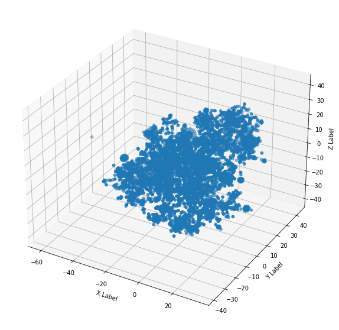

```python
fig = plt.figure(figsize = (20,10))
ax = fig.add_subplot(projection='3d'
                    )

# For each set of style and range settings, plot n random points in the box
# defined by x in [23, 32], y in [0, 100], z in [zlow, zhigh].

ax.scatter(order_matrix_tsne[:,0],
           order_matrix_tsne[:,1],
           order_matrix_tsne[:,2]
          )

ax.set_xlabel('X Label')
ax.set_ylabel('Y Label')
ax.set_zlabel('Z Label')

plt.show()
```

소결론 : T-SNE를 이용한 차원축소는 활용하기가 어렵다.